# Biostat 212a Homework 4

Due Mar. 10, 2026 @ 11:59PM

Author

YOUR NAME and UID

Published

March 11, 2026

## 1 ISL Exercise 8.4.3 (10pts)

Consider the Gini index, classification error, and entropy in a simple classification setting with two classes. Create a single plot that displays each of these quantities as a function of $p̂_{m1}$ .

- The x-axis should display $p̂_{m1}$ , ranging from 0 to 1, and the y-axis should display the value of the Gini index, classification error, and entropy.
- Hint: In a setting with two classes, $p̂_{m1}$ = 1 − $p̂_{m2}$ . You could make this plot by hand, but it will be much easier to make in R.

$p̂_{m1}$ is the proportion of class 1 observations in the m-th region, and $p̂_{m2}$ is the proportion of class 2 observations in the m-th region. The formulas for the Gini index, classification error, and entropy are as follows:

Gini Index: $G = 1 - p̂_{m1}^2 - p̂_{m2}^2$  
Classification Error: $E = 1 - max(p̂_{m1}, p̂_{m2})$  
Entropy: $H = -p̂_{m1} log(p̂_{m1}) - p̂_{m2} log(p̂_{m2})$

- ~ define 0 log(0) = 0 (so we don’t get undefined values)

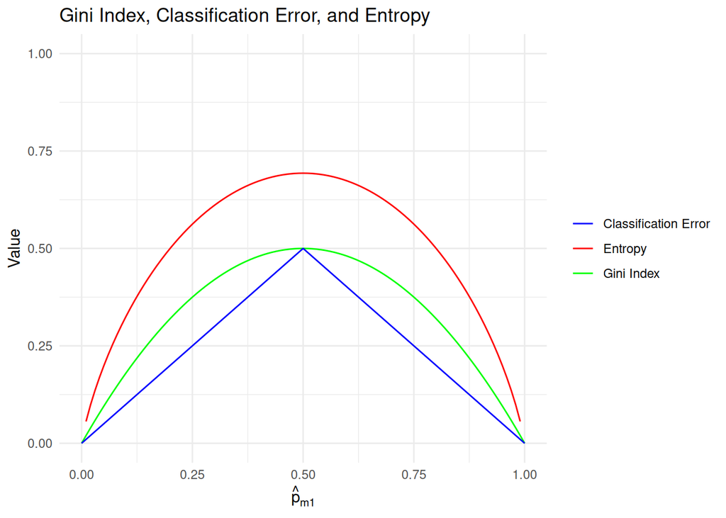

```r
library(ggplot2)

# Create a object to store values of p̂_{m1} & p̂_{m2} (reciprocal)
p_m1 <- seq(0, 1, by = 0.01)
p_m2 <- 1 - p_m1

probabilities <- data.frame(p_m1, p_m2)

ggplot(probabilities, aes(x = p_m1)) +
  geom_line(aes(y = 1 - p_m1^2 - p_m2^2, color = "Gini Index")) +
  geom_line(aes(y = 1 - pmax(p_m1, p_m2), color = "Classification Error")) +
  geom_line(aes(y = -p_m1 * log(p_m1) - p_m2 * log(p_m2), color = "Entropy")) +
  labs(x = expression(hat(p)[m1]), y = "Value", title = "Gini Index, Classification Error, and Entropy") +
  scale_color_manual(values = c("blue", "red", "green")) +
  theme_minimal() +
  theme(legend.title = element_blank()) +
  scale_y_continuous(limits = c(0, 1))
```

## 2 ISL Exercise 8.4.4 (10pts)

This question relates to the plots in Figure 8.14.

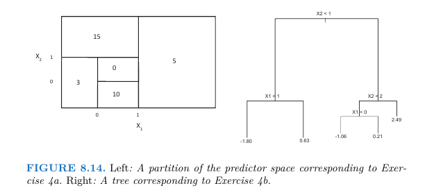

1. Sketch the tree corresponding to the partition of the predictor space illustrated in the left-hand panel of Figure 8.14. The num- bers inside the boxes indicate the mean of Y within each region.

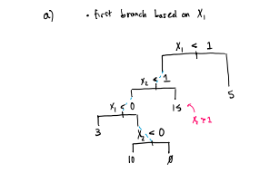

2. Create a diagram similar to the left-hand panel of Figure 8.14, using the tree illustrated in the right-hand panel of the same figure. You should divide up the predictor space into the correct regions, and indicate the mean for each region.

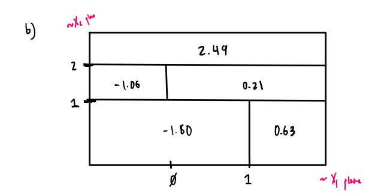

## 3 ISL Exercise 8.4.5 (10pts)

Suppose we produce ten bootstrapped samples from a data set containing red and green classes. We then apply a classification tree to each bootstrapped sample and, for a specific value of X, produce 10 estimates of P (Class is Red|X):

0.1, 0.15, 0.2, 0.2, 0.55, 0.6, 0.6, 0.65, 0.7, and 0.75.

There are two common ways to combine these results together into a single class prediction. One is the majority vote approach discussed in this chapter. The second approach is to classify based on the average probability. In this example, what is the final classification under each of these two approaches?

“majority vote: the overall prediction is the most commonly occurring majority class among B (# of bootstrapped training sets) predictions”

- we look at the 10 estimates of P (Class is Red|X) and classify as Red if the majority of these estimates are greater than 0.5, and classify as Green otherwise.
- in this case, we have 6 estimates greater than 0.5 (0.55, 0.6, 0.6, 0.65, 0.7, and 0.75) and 4 estimates less than or equal to 0.5 (0.1, 0.15, 0.2, and 0.2). Therefore, the majority vote approach would classify this observation as **Red**.

With the average probability approach, we calculate the average of the 10 estimates of P (Class is Red|X):

- Average probability = (0.1 + 0.15 + 0.2 + 0.2 + 0.55 + 0.6 + 0.6 + 0.65 + 0.7 + 0.75) / 10 = 4.5 / 10 = 0.45
- Since the average probability of P (Class is Red|X) is less than 0.5, the average probability approach would classify this observation as **Green**.

## 4 ISL Lab 8.3. `Boston` data set (30pts)

Follow the machine learning workflow to train regression tree, random forest, and boosting methods for predicting `medv`. Evaluate out-of-sample performance on a test set.

```r
library(GGally)
library(gtsummary)
library(ranger) # https://cran.r-project.org/web/packages/ranger/index.html
library(tidyverse)
library(tidymodels)
library(ISLR2)

library(rpart.plot) # visualize the tree structure
library(vip)        # variable importance plot
```

### 4.1 Pre-processing

```r
data(Boston)
Boston <- as_tibble(Boston) %>%
  filter(!is.na(medv)) # remove rows with missing values in the response variable

glimpse(Boston)
```

```
Rows: 506
Columns: 13
$ crim    <dbl> 0.00632, 0.02731, 0.02729, 0.03237, 0.06905, 0.02985, 0.08829,…
$ zn      <dbl> 18.0, 0.0, 0.0, 0.0, 0.0, 0.0, 12.5, 12.5, 12.5, 12.5, 12.5, 1…
$ indus   <dbl> 2.31, 7.07, 7.07, 2.18, 2.18, 2.18, 7.87, 7.87, 7.87, 7.87, 7.…
$ chas    <int> 0, 0, 0, 0, 0, 0, 0, 0, 0, 0, 0, 0, 0, 0, 0, 0, 0, 0, 0, 0, 0,…
$ nox     <dbl> 0.538, 0.469, 0.469, 0.458, 0.458, 0.458, 0.524, 0.524, 0.524,…
$ rm      <dbl> 6.575, 6.421, 7.185, 6.998, 7.147, 6.430, 6.012, 6.172, 5.631,…
$ age     <dbl> 65.2, 78.9, 61.1, 45.8, 54.2, 58.7, 66.6, 96.1, 100.0, 85.9, 9…
$ dis     <dbl> 4.0900, 4.9671, 4.9671, 6.0622, 6.0622, 6.0622, 5.5605, 5.9505…
$ rad     <int> 1, 2, 2, 3, 3, 3, 5, 5, 5, 5, 5, 5, 5, 4, 4, 4, 4, 4, 4, 4, 4,…
$ tax     <dbl> 296, 242, 242, 222, 222, 222, 311, 311, 311, 311, 311, 311, 31…
$ ptratio <dbl> 15.3, 17.8, 17.8, 18.7, 18.7, 18.7, 15.2, 15.2, 15.2, 15.2, 15…
$ lstat   <dbl> 4.98, 9.14, 4.03, 2.94, 5.33, 5.21, 12.43, 19.15, 29.93, 17.10…
$ medv    <dbl> 24.0, 21.6, 34.7, 33.4, 36.2, 28.7, 22.9, 27.1, 16.5, 18.9, 15…
```

```r
# Brief Feature Engineering
# chas and rad as factor variables
Boston <- Boston %>%
  mutate(chas = as.factor(chas),
          rad = as.factor(rad))
```

### 4.2 Initial Splitting

```r
set.seed(321)
Boston_split <- initial_split(Boston, prop = 0.5)
Boston_split
```

```
<Training/Testing/Total>
<253/253/506>
```

```r
Boston_train <- training(Boston_split)
Boston_test <- testing(Boston_split)
dim(Boston_train)
```

```
[1] 253  13
```

```r
dim(Boston_test)
```

```
[1] 253  13
```

### 4.3 Recipe/Pipeline creation

```r
reg_tree_recipe <-
  recipe(
    medv ~ .,
    data = Boston_train
  ) %>%
  # step may not be necessary due to pre-processing, but we include it for completeness
  step_naomit(medv) %>%
  # zero-variance filter for numeric predictor variables
  step_zv(all_numeric_predictors()) # %>%
  # estimate the means and standard deviations
  # prep(training = Hitters_other, retain = TRUE)

reg_tree_recipe
```

### 4.4 Model specification

https://parsnip.tidymodels.org/reference/decision_tree.html

```r
regression_tree_spec <- decision_tree(
  mode = "regression", # regression tree for prediction task
  cost_complexity = tune(),
  tree_depth = tune(),
  min_n = 5,
  engine = "rpart"
)
# %>% set_engine("rpart", control = rpart.control(cp = 0.01, maxdepth = 5, minsplit = 10))
```

### 4.5 Pipeline creation & Tuning Grid

```r
reg_tree_wf <- workflow() %>%
  add_recipe(reg_tree_recipe) %>%
  add_model(regression_tree_spec)
reg_tree_wf
```

```
══ Workflow ════════════════════════════════════════════════════════════════════
Preprocessor: Recipe
Model: decision_tree()

── Preprocessor ────────────────────────────────────────────────────────────────
2 Recipe Steps

• step_naomit()
• step_zv()

── Model ───────────────────────────────────────────────────────────────────────
Decision Tree Model Specification (regression)

Main Arguments:
  cost_complexity = tune()
  tree_depth = tune()
  min_n = 5

Computational engine: rpart
```

“ccp_alpha is the Minimal Cost-Complexity Pruning parameter. Greater values of ccp_alpha increase the number of nodes pruned.”

```r
tree_grid <- grid_regular(cost_complexity(),
                          tree_depth(),
                          levels = c(100, 5))
```

### 4.6 Cross Validation & Visualization

```r
set.seed(321)
Boston_folds <- vfold_cv(Boston_train, v = 5)
Boston_folds
```

```
#  5-fold cross-validation
# A tibble: 5 × 2
  splits           id
  <list>           <chr>
1 <split [202/51]> Fold1
2 <split [202/51]> Fold2
3 <split [202/51]> Fold3
4 <split [203/50]> Fold4
5 <split [203/50]> Fold5
```

```r
reg_tree_fit <- reg_tree_wf %>%
  tune_grid(
    resamples = Boston_folds,
    grid = tree_grid,
    control = control_grid(save_pred = TRUE)
  )
reg_tree_fit
```

```
# Tuning results
# 5-fold cross-validation
# A tibble: 5 × 5
  splits           id    .metrics             .notes           .predictions
  <list>           <chr> <list>               <list>           <list>
1 <split [202/51]> Fold1 <tibble [1,000 × 6]> <tibble [0 × 4]> <tibble>
2 <split [202/51]> Fold2 <tibble [1,000 × 6]> <tibble [0 × 4]> <tibble>
3 <split [202/51]> Fold3 <tibble [1,000 × 6]> <tibble [0 × 4]> <tibble>
4 <split [203/50]> Fold4 <tibble [1,000 × 6]> <tibble [0 × 4]> <tibble>
5 <split [203/50]> Fold5 <tibble [1,000 × 6]> <tibble [0 × 4]> <tibble>
```

```
# A tibble: 1,000 × 8
   cost_complexity tree_depth .metric .estimator  mean     n std_err
             <dbl>      <int> <chr>   <chr>      <dbl> <int>   <dbl>
 1    0.0000000001          1 rmse    standard   7.13      5  0.263
 2    0.0000000001          1 rsq     standard   0.361     5  0.0231
 3    0.0000000001          4 rmse    standard   4.59      5  0.471
 4    0.0000000001          4 rsq     standard   0.735     5  0.0554
 5    0.0000000001          8 rmse    standard   4.69      5  0.458
 6    0.0000000001          8 rsq     standard   0.729     5  0.0419
 7    0.0000000001         11 rmse    standard   4.68      5  0.461
 8    0.0000000001         11 rsq     standard   0.732     5  0.0429
 9    0.0000000001         15 rmse    standard   4.70      5  0.455
10    0.0000000001         15 rsq     standard   0.730     5  0.0420
   .config
   <chr>
 1 pre0_mod001_post0
 2 pre0_mod001_post0
 3 pre0_mod002_post0
 4 pre0_mod002_post0
 5 pre0_mod003_post0
 6 pre0_mod003_post0
 7 pre0_mod004_post0
 8 pre0_mod004_post0
 9 pre0_mod005_post0
10 pre0_mod005_post0
# ℹ 990 more rows
```

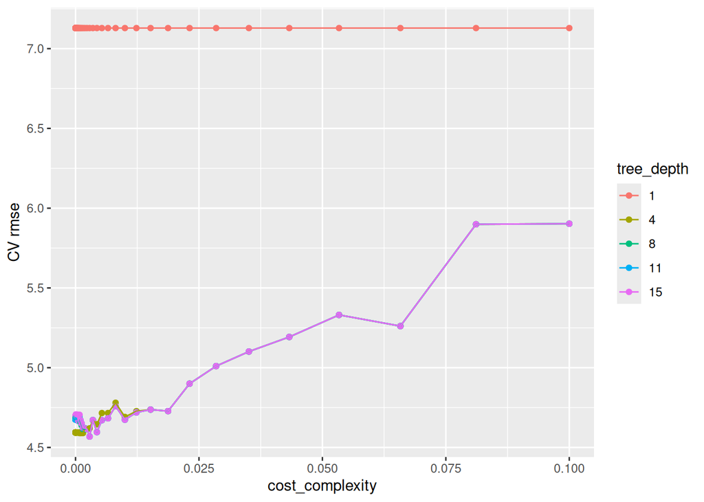

```r
# visualize tuning results

reg_tree_fit %>%
  collect_metrics() %>%
  print(width = Inf) %>%
  filter(.metric == "rmse") %>%
  mutate(tree_depth = as.factor(tree_depth)) %>%
  ggplot(mapping = aes(x = cost_complexity, y = mean, color = tree_depth)) +
  geom_point() +
  geom_line() +
  labs(x = "cost_complexity", y = "CV rmse")
```

We see that stump underfits, deeper trees do better, and too much pruning hurts performance.

### 4.7 Identify the best model and evaluate on the test set

```r
reg_tree_fit %>%
  show_best(metric = "rmse")
```

```
# A tibble: 5 × 8
  cost_complexity tree_depth .metric .estimator  mean     n std_err .config
            <dbl>      <int> <chr>   <chr>      <dbl> <int>   <dbl> <chr>
1        0.00285           8 rmse    standard    4.57     5   0.454 pre0_mod413…
2        0.00285          11 rmse    standard    4.57     5   0.454 pre0_mod414…
3        0.00285          15 rmse    standard    4.57     5   0.454 pre0_mod415…
4        0.000811          4 rmse    standard    4.59     5   0.469 pre0_mod382…
5        0.001             4 rmse    standard    4.59     5   0.469 pre0_mod387…
```

```r
best_reg_tree <- reg_tree_fit %>%
  select_best(metric = "rmse")
best_reg_tree
```

```
# A tibble: 1 × 3
  cost_complexity tree_depth .config
            <dbl>      <int> <chr>
1         0.00285          8 pre0_mod413_post0
```

The best model has a tree depth of 8. (not at the min or max so it is not a boundary case)

```r
final_reg_tree_wf <- reg_tree_wf %>%
  finalize_workflow(best_reg_tree)
final_reg_tree_wf
```

```
══ Workflow ════════════════════════════════════════════════════════════════════
Preprocessor: Recipe
Model: decision_tree()

── Preprocessor ────────────────────────────────────────────────────────────────
2 Recipe Steps

• step_naomit()
• step_zv()

── Model ───────────────────────────────────────────────────────────────────────
Decision Tree Model Specification (regression)

Main Arguments:
  cost_complexity = 0.0028480358684358
  tree_depth = 8
  min_n = 5

Computational engine: rpart
```

```r
# Fit the whole training set, then evaluate on the test set
final_reg_tree_fit <- final_reg_tree_wf %>%
  last_fit(Boston_split)

# compile metrics
final_reg_tree_fit %>%
  collect_metrics()
```

```
# A tibble: 2 × 4
  .metric .estimator .estimate .config
  <chr>   <chr>          <dbl> <chr>
1 rmse    standard       4.34  pre0_mod0_post0
2 rsq     standard       0.794 pre0_mod0_post0
```

### 4.8 Visuallize the final regression tree

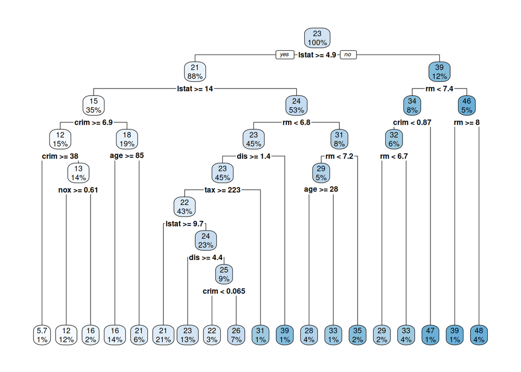

```r
final_reg_tree <- extract_workflow(final_reg_tree_fit)

# shows the tree structure with the splits and the mean values in each terminal node
final_reg_tree %>%
  extract_fit_engine() %>%
  rpart.plot(roundint = FALSE)
```

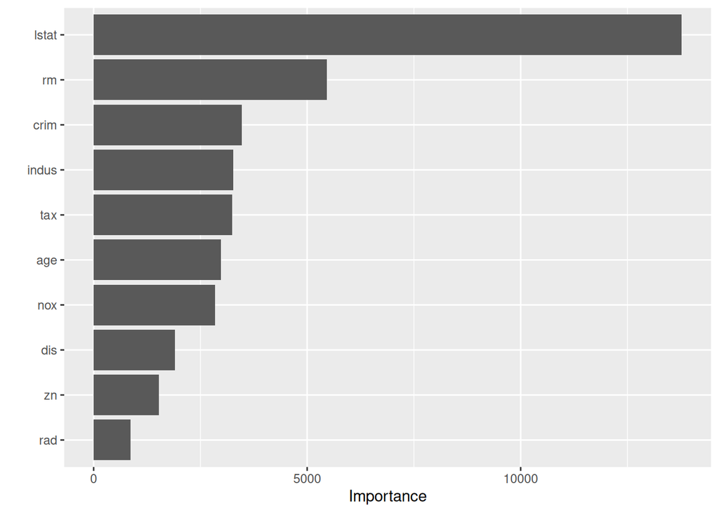

```r
# ~ variable importance plot (gini importance)
final_reg_tree %>%
  extract_fit_engine() %>%
  vip(num_features = 10)
```

## 5 ISL Lab 8.3 `Carseats` data set (30pts)

Follow the machine learning workflow to train classification tree, random forest, and boosting methods for classifying `Sales <= 8` versus `Sales > 8`. Evaluate out-of-sample performance on a test set.

### 5.1 Pre-processing

```r
# library(ISLR2)

data(Carseats)
Carseats <- as_tibble(Carseats) %>%
  filter(!is.na(Sales)) # remove rows with missing values in the response variable
glimpse(Carseats)
```

```
Rows: 400
Columns: 11
$ Sales       <dbl> 9.50, 11.22, 10.06, 7.40, 4.15, 10.81, 6.63, 11.85, 6.54, …
$ CompPrice   <dbl> 138, 111, 113, 117, 141, 124, 115, 136, 132, 132, 121, 117…
$ Income      <dbl> 73, 48, 35, 100, 64, 113, 105, 81, 110, 113, 78, 94, 35, 2…
$ Advertising <dbl> 11, 16, 10, 4, 3, 13, 0, 15, 0, 0, 9, 4, 2, 11, 11, 5, 0, …
$ Population  <dbl> 276, 260, 269, 466, 340, 501, 45, 425, 108, 131, 150, 503,…
$ Price       <dbl> 120, 83, 80, 97, 128, 72, 108, 120, 124, 124, 100, 94, 136…
$ ShelveLoc   <fct> Bad, Good, Medium, Medium, Bad, Bad, Medium, Good, Medium,…
$ Age         <dbl> 42, 65, 59, 55, 38, 78, 71, 67, 76, 76, 26, 50, 62, 53, 52…
$ Education   <dbl> 17, 10, 12, 14, 13, 16, 15, 10, 10, 17, 10, 13, 18, 18, 18…
$ Urban       <fct> Yes, Yes, Yes, Yes, Yes, No, Yes, Yes, No, No, No, Yes, Ye…
$ US          <fct> Yes, Yes, Yes, Yes, No, Yes, No, Yes, No, Yes, Yes, Yes, N…
```

```r
# Documentation: https://rdrr.io/cran/ISLR2/man/Carseats.html

# create a new binary variable for classification ~ factor variable
# Urban and US alredy coded as factor variables
Carseats <- Carseats %>%
  mutate(
    Sales_Level = factor(if_else(Sales <= 8, "Low", "High"),
                         levels = c("Low", "High"))
  ) %>%
  select(-Sales)
```

### 5.2 Initial Splitting

```r
set.seed(321)
Carseats_split <- initial_split(Carseats,
    prop = 0.5,
    strata = Sales_Level
    )
Carseats_split
```

```
<Training/Testing/Total>
<200/200/400>
```

```r
Carseats_train <- training(Carseats_split)
Carseats_test <- testing(Carseats_split)

dim(Carseats_train)
```

```
[1] 200  11
```

```r
dim(Carseats_test)
```

```
[1] 200  11
```

### 5.3 Recipe/Pipeline creation

```r
class_tree_recipe <-
  recipe(
    Sales_Level ~ .,
    data = Carseats_train
  ) %>%
  step_naomit(Sales_Level) %>%
  # zero-variance filter for numeric predictor variables
  step_zv(all_numeric_predictors()) # %>%
  # estimate the means and standard deviations
  # prep(training = Hitters_other, retain = TRUE)
class_tree_recipe
```

### 5.4 Model specification

```r
class_tree_spec <- decision_tree(
  mode = "classification", # classification tree for classification task
  cost_complexity = tune(),
  tree_depth = tune(),
  min_n = 5,
  engine = "rpart"
)
```

### 5.5 Pipeline creation & Tuning Grid

```r
class_tree_wf <- workflow() %>%
  add_recipe(class_tree_recipe) %>%
  add_model(class_tree_spec)
class_tree_wf
```

```
══ Workflow ════════════════════════════════════════════════════════════════════
Preprocessor: Recipe
Model: decision_tree()

── Preprocessor ────────────────────────────────────────────────────────────────
2 Recipe Steps

• step_naomit()
• step_zv()

── Model ───────────────────────────────────────────────────────────────────────
Decision Tree Model Specification (classification)

Main Arguments:
  cost_complexity = tune()
  tree_depth = tune()
  min_n = 5

Computational engine: rpart
```

```r
# utilize the same grid; evaluation of this chunk set to false
tree_grid <- grid_regular(cost_complexity(),
                          tree_depth(),
                          levels = c(100, 5))
```

### 5.6 Cross Validation & Visualization

```r
set.seed(321)

# ~ Incorporation of strata within the cross validation folds
Carseats_fold <- vfold_cv(Carseats_train, v = 5, strata = Sales_Level)
Carseats_fold
```

```
#  5-fold cross-validation using stratification
# A tibble: 5 × 2
  splits           id
  <list>           <chr>
1 <split [159/41]> Fold1
2 <split [159/41]> Fold2
3 <split [160/40]> Fold3
4 <split [161/39]> Fold4
5 <split [161/39]> Fold5
```

```r
class_tree_fit <- class_tree_wf %>%
  tune_grid(
    resamples = Carseats_fold,
    grid = tree_grid,
    metrics = metric_set(accuracy, roc_auc)
  )
class_tree_fit
```

```
# Tuning results
# 5-fold cross-validation using stratification
# A tibble: 5 × 4
  splits           id    .metrics             .notes
  <list>           <chr> <list>               <list>
1 <split [159/41]> Fold1 <tibble [1,000 × 6]> <tibble [0 × 4]>
2 <split [159/41]> Fold2 <tibble [1,000 × 6]> <tibble [0 × 4]>
3 <split [160/40]> Fold3 <tibble [1,000 × 6]> <tibble [0 × 4]>
4 <split [161/39]> Fold4 <tibble [1,000 × 6]> <tibble [0 × 4]>
5 <split [161/39]> Fold5 <tibble [1,000 × 6]> <tibble [0 × 4]>
```

```
# A tibble: 1,000 × 8
   cost_complexity tree_depth .metric  .estimator  mean     n std_err
             <dbl>      <int> <chr>    <chr>      <dbl> <int>   <dbl>
 1    0.0000000001          1 accuracy binary     0.635     5  0.0247
 2    0.0000000001          1 roc_auc  binary     0.564     5  0.0289
 3    0.0000000001          4 accuracy binary     0.725     5  0.0414
 4    0.0000000001          4 roc_auc  binary     0.742     5  0.0466
 5    0.0000000001          8 accuracy binary     0.739     5  0.0358
 6    0.0000000001          8 roc_auc  binary     0.777     5  0.0350
 7    0.0000000001         11 accuracy binary     0.724     5  0.0328
 8    0.0000000001         11 roc_auc  binary     0.744     5  0.0378
 9    0.0000000001         15 accuracy binary     0.724     5  0.0328
10    0.0000000001         15 roc_auc  binary     0.744     5  0.0378
   .config
   <chr>
 1 pre0_mod001_post0
 2 pre0_mod001_post0
 3 pre0_mod002_post0
 4 pre0_mod002_post0
 5 pre0_mod003_post0
 6 pre0_mod003_post0
 7 pre0_mod004_post0
 8 pre0_mod004_post0
 9 pre0_mod005_post0
10 pre0_mod005_post0
# ℹ 990 more rows
```

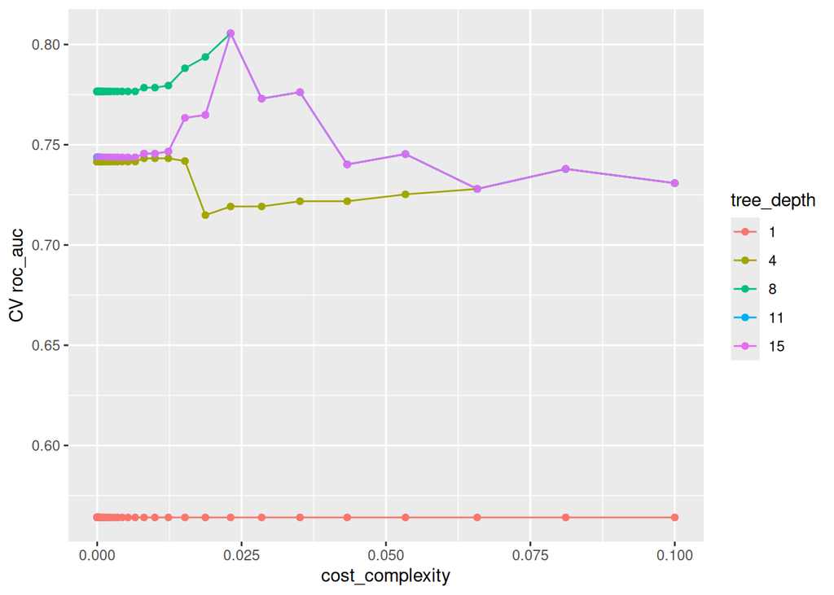

```r
class_tree_fit %>%
  collect_metrics() %>%
  print(width = Inf) %>%
  filter(.metric == "roc_auc") %>%
  mutate(tree_depth = as.factor(tree_depth)) %>%
  ggplot(mapping = aes(x = cost_complexity, y = mean, color = tree_depth)) +
  geom_point() +
  geom_line() +
  labs(x = "cost_complexity", y = "CV roc_auc")
```

The red line (tree_depth = 1) sits around 0.56 AUC, which is only slightly better than random guessing (0.50) showing that the stump underfits. moderate depth + moderate pruning → best AUC and heavier pruning hurts performance.

### 5.7 Identify the best model and evaluate on the test set

~ Evaluate out-of-sample performance on a test set.

```r
class_tree_fit %>%
  show_best(metric = "accuracy")
```

```
# A tibble: 5 × 8
  cost_complexity tree_depth .metric  .estimator  mean     n std_err .config
            <dbl>      <int> <chr>    <chr>      <dbl> <int>   <dbl> <chr>
1          0.0231          8 accuracy binary     0.779     5  0.0319 pre0_mod46…
2          0.0231         11 accuracy binary     0.779     5  0.0319 pre0_mod46…
3          0.0231         15 accuracy binary     0.779     5  0.0319 pre0_mod46…
4          0.0187          8 accuracy binary     0.779     5  0.0359 pre0_mod45…
5          0.0187         11 accuracy binary     0.769     5  0.0300 pre0_mod45…
```

```r
best_class_tree <- class_tree_fit %>%
  select_best(metric = "accuracy")
best_class_tree
```

```
# A tibble: 1 × 3
  cost_complexity tree_depth .config
            <dbl>      <int> <chr>
1          0.0231          8 pre0_mod463_post0
```

The best model has a tree depth of 8. (not at the min or max so it is not a boundary case)

```r
final_class_tree_wf <- class_tree_wf %>%
  finalize_workflow(best_class_tree)
final_class_tree_wf
```

```
══ Workflow ════════════════════════════════════════════════════════════════════
Preprocessor: Recipe
Model: decision_tree()

── Preprocessor ────────────────────────────────────────────────────────────────
2 Recipe Steps

• step_naomit()
• step_zv()

── Model ───────────────────────────────────────────────────────────────────────
Decision Tree Model Specification (classification)

Main Arguments:
  cost_complexity = 0.0231012970008316
  tree_depth = 8
  min_n = 5

Computational engine: rpart
```

```r
final_class_tree_fit <- final_class_tree_wf %>%
  last_fit(Carseats_split)

final_class_tree_fit %>%
  collect_metrics()
```

```
# A tibble: 3 × 4
  .metric     .estimator .estimate .config
  <chr>       <chr>          <dbl> <chr>
1 accuracy    binary         0.78  pre0_mod0_post0
2 roc_auc     binary         0.771 pre0_mod0_post0
3 brier_class binary         0.188 pre0_mod0_post0
```

### 5.8 Visuallize the final classification tree

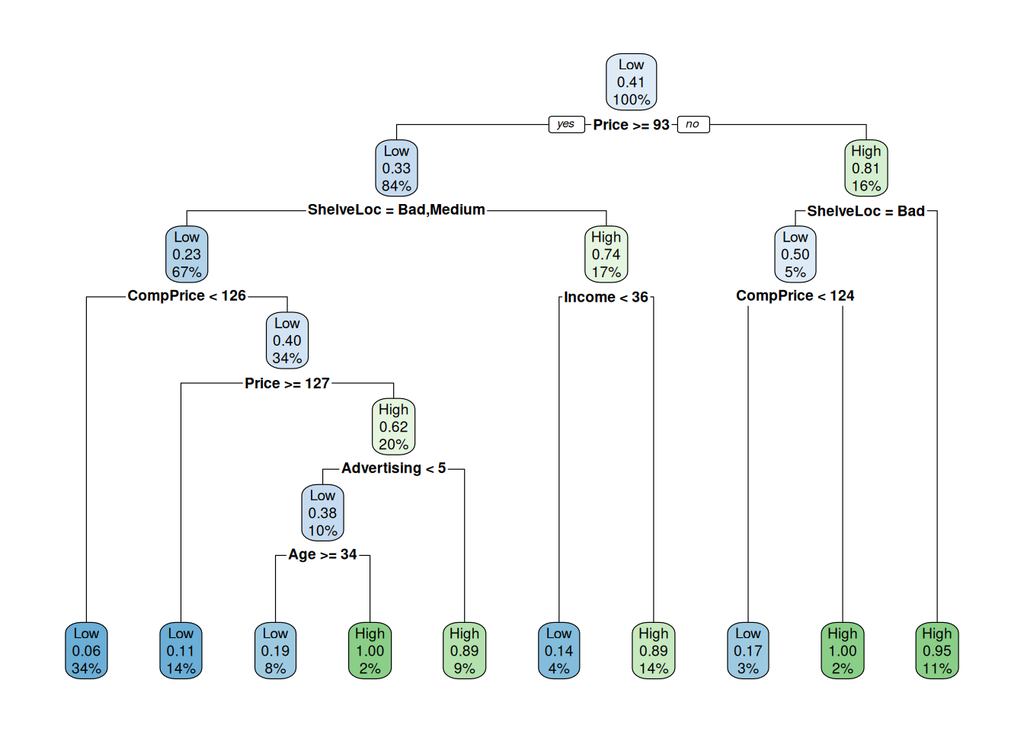

```r
final_class_tree <- extract_workflow(final_class_tree_fit)

# shows the tree structure with the splits and the mean values in each terminal node
final_class_tree %>%
  extract_fit_engine() %>%
  rpart.plot(roundint = FALSE)
```

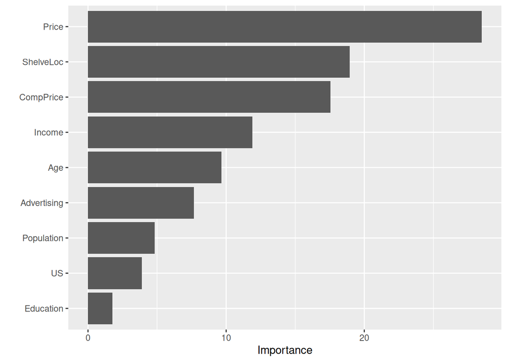

```r
# ~ variable importance plot (gini importance)
final_class_tree %>%
  extract_fit_engine() %>%
  vip(num_features = 10)
```